# Project: Investigate a Dataset - [Patients with no-show appointments]

- Introduction
- Data Wrangling
- Exploratory Data Analysis
- Conclusions

## Introduction

This dataset collects information from 100k medical appointments in Brazil and is focused on the question of whether or not patients show up for their appointment. A number of characteristics about the patient are included in each row.

● ‘ScheduledDay’ tells us on what day the patient set up their appointment.

● ‘Neighborhood’ indicates the location of the hospital.

● ‘Scholarship’ indicates whether or not the patient is enrolled in Brasilian welfare program Bolsa Família.

● Be careful about the encoding of the last column: it says ‘No’ if the patient showed up to their appointment, and ‘Yes’ if they did not show up.

### Dataset Description

There is a csv file that contain the data that will be analyzed in this project.

### Question(s) for Analysis

What factors are important for us to know in order to predict if a patient will show up for their scheduled appointment.

```python
# Use this cell to set up import statements for all of the packages that you
#   plan to use.
import pandas as pd
import numpy as np
import matplotlib.pyplot as plt
import seaborn as snb
%matplotlib inline
```

## Data Wrangling

Here the data for the report will be loaded, check if the data is clean, and then trim and clean for analysis.

### General Properties

```python
# Load your data and print out a few lines. Perform operations to inspect data
#   types and look for instances of missing or possibly errant data.
df=pd.read_csv('noshowappointments-kagglev2-may-2016.csv')
df.head()
```

|  | PatientId | AppointmentID | Gender | ScheduledDay | AppointmentDay | Age | Neighbourhood | Scholarship | Hipertension | Diabetes | Alcoholism | Handcap | SMS_received | No-show |
| --- | --- | --- | --- | --- | --- | --- | --- | --- | --- | --- | --- | --- | --- | --- |
| 0 | 2.987250e+13 | 5642903 | F | 2016-04-29T18:38:08Z | 2016-04-29T00:00:00Z | 62 | JARDIM DA PENHA | 0 | 1 | 0 | 0 | 0 | 0 | No |
| 1 | 5.589978e+14 | 5642503 | M | 2016-04-29T16:08:27Z | 2016-04-29T00:00:00Z | 56 | JARDIM DA PENHA | 0 | 0 | 0 | 0 | 0 | 0 | No |
| 2 | 4.262962e+12 | 5642549 | F | 2016-04-29T16:19:04Z | 2016-04-29T00:00:00Z | 62 | MATA DA PRAIA | 0 | 0 | 0 | 0 | 0 | 0 | No |
| 3 | 8.679512e+11 | 5642828 | F | 2016-04-29T17:29:31Z | 2016-04-29T00:00:00Z | 8 | PONTAL DE CAMBURI | 0 | 0 | 0 | 0 | 0 | 0 | No |
| 4 | 8.841186e+12 | 5642494 | F | 2016-04-29T16:07:23Z | 2016-04-29T00:00:00Z | 56 | JARDIM DA PENHA | 0 | 1 | 1 | 0 | 0 | 0 | No |

```python
#exploring data shape
df.shape
```

```
(110527, 14)
```

**Data consist of 110527 appointment rows and 14 columns**

```python
#checking for duplicate
df.duplicated().sum()
```

```
0
```

**The rows has no duplicate**

```python
#checking for numbers of unique values
df['PatientId'].nunique()
```

```
62299
```

**62299 patient out of 110527 have unique value**

```python
#checking the number of patients with duplicated id
df['PatientId'].duplicated().sum()
```

```
48228
```

**The patients with duplicated id are 48228**

```python
#checking the number of duplicated patients ids and noshow
#to know if there were patients ids duplicated but different from the no show status
df.duplicated(['PatientId', 'No-show']).sum()
```

```
38710
```

**38710 patients ids have same status os showing or not showing. This will be removed during the cleaning data stage.**

```python
#checking for missing values
df.info()
```

```
<class 'pandas.core.frame.DataFrame'>
RangeIndex: 110527 entries, 0 to 110526
Data columns (total 14 columns):
 #   Column          Non-Null Count   Dtype
---  ------          --------------   -----
 0   PatientId       110527 non-null  float64
 1   AppointmentID   110527 non-null  int64
 2   Gender          110527 non-null  object
 3   ScheduledDay    110527 non-null  object
 4   AppointmentDay  110527 non-null  object
 5   Age             110527 non-null  int64
 6   Neighbourhood   110527 non-null  object
 7   Scholarship     110527 non-null  int64
 8   Hipertension    110527 non-null  int64
 9   Diabetes        110527 non-null  int64
 10  Alcoholism      110527 non-null  int64
 11  Handcap         110527 non-null  int64
 12  SMS_received    110527 non-null  int64
 13  No-show         110527 non-null  object
dtypes: float64(1), int64(8), object(5)
memory usage: 11.8+ MB
```

**There is no missing values**

```python
#getting information about the date
df.describe()
```

|  | PatientId | AppointmentID | Age | Scholarship | Hipertension | Diabetes | Alcoholism | Handcap | SMS_received |
| --- | --- | --- | --- | --- | --- | --- | --- | --- | --- |
| count | 1.105270e+05 | 1.105270e+05 | 110527.000000 | 110527.000000 | 110527.000000 | 110527.000000 | 110527.000000 | 110527.000000 | 110527.000000 |
| mean | 1.474963e+14 | 5.675305e+06 | 37.088874 | 0.098266 | 0.197246 | 0.071865 | 0.030400 | 0.022248 | 0.321026 |
| std | 2.560949e+14 | 7.129575e+04 | 23.110205 | 0.297675 | 0.397921 | 0.258265 | 0.171686 | 0.161543 | 0.466873 |
| min | 3.921784e+04 | 5.030230e+06 | -1.000000 | 0.000000 | 0.000000 | 0.000000 | 0.000000 | 0.000000 | 0.000000 |
| 25% | 4.172614e+12 | 5.640286e+06 | 18.000000 | 0.000000 | 0.000000 | 0.000000 | 0.000000 | 0.000000 | 0.000000 |
| 50% | 3.173184e+13 | 5.680573e+06 | 37.000000 | 0.000000 | 0.000000 | 0.000000 | 0.000000 | 0.000000 | 0.000000 |
| 75% | 9.439172e+13 | 5.725524e+06 | 55.000000 | 0.000000 | 0.000000 | 0.000000 | 0.000000 | 0.000000 | 1.000000 |
| max | 9.999816e+14 | 5.790484e+06 | 115.000000 | 1.000000 | 1.000000 | 1.000000 | 1.000000 | 4.000000 | 1.000000 |

**Majority of the patients are not handcap**

```python
mask=df.query('Age==-1')
mask
```

|  | PatientId | AppointmentID | Gender | ScheduledDay | AppointmentDay | Age | Neighbourhood | Scholarship | Hipertension | Diabetes | Alcoholism | Handcap | SMS_received | No-show |
| --- | --- | --- | --- | --- | --- | --- | --- | --- | --- | --- | --- | --- | --- | --- |
| 99832 | 4.659432e+14 | 5775010 | F | 2016-06-06T08:58:13Z | 2016-06-06T00:00:00Z | -1 | ROMÃO | 0 | 0 | 0 | 0 | 0 | 0 | No |

### Data Cleaning

```python
#removing the the row with -1 value
df.drop(index=99832,inplace=True)
```

```python
df.describe()
```

|  | PatientId | AppointmentID | Age | Scholarship | Hipertension | Diabetes | Alcoholism | Handcap | SMS_received |
| --- | --- | --- | --- | --- | --- | --- | --- | --- | --- |
| count | 1.105260e+05 | 1.105260e+05 | 110526.000000 | 110526.000000 | 110526.000000 | 110526.000000 | 110526.000000 | 110526.000000 | 110526.000000 |
| mean | 1.474934e+14 | 5.675304e+06 | 37.089219 | 0.098266 | 0.197248 | 0.071865 | 0.030400 | 0.022248 | 0.321029 |
| std | 2.560943e+14 | 7.129544e+04 | 23.110026 | 0.297676 | 0.397923 | 0.258266 | 0.171686 | 0.161543 | 0.466874 |
| min | 3.921784e+04 | 5.030230e+06 | 0.000000 | 0.000000 | 0.000000 | 0.000000 | 0.000000 | 0.000000 | 0.000000 |
| 25% | 4.172536e+12 | 5.640285e+06 | 18.000000 | 0.000000 | 0.000000 | 0.000000 | 0.000000 | 0.000000 | 0.000000 |
| 50% | 3.173184e+13 | 5.680572e+06 | 37.000000 | 0.000000 | 0.000000 | 0.000000 | 0.000000 | 0.000000 | 0.000000 |
| 75% | 9.438963e+13 | 5.725523e+06 | 55.000000 | 0.000000 | 0.000000 | 0.000000 | 0.000000 | 0.000000 | 1.000000 |
| max | 9.999816e+14 | 5.790484e+06 | 115.000000 | 1.000000 | 1.000000 | 1.000000 | 1.000000 | 4.000000 | 1.000000 |

```python
#renaming the 'No-show' column to faccilitate analysis and correcting 'Hipertension'spelling
df.rename(columns={'Hipertension': 'Hypertension'}, inplace=True)
df.rename(columns={'No-show': 'No_show'}, inplace=True)
df.head()
```

|  | PatientId | AppointmentID | Gender | ScheduledDay | AppointmentDay | Age | Neighbourhood | Scholarship | Hypertension | Diabetes | Alcoholism | Handcap | SMS_received | No_show |
| --- | --- | --- | --- | --- | --- | --- | --- | --- | --- | --- | --- | --- | --- | --- |
| 0 | 2.987250e+13 | 5642903 | F | 2016-04-29T18:38:08Z | 2016-04-29T00:00:00Z | 62 | JARDIM DA PENHA | 0 | 1 | 0 | 0 | 0 | 0 | No |
| 1 | 5.589978e+14 | 5642503 | M | 2016-04-29T16:08:27Z | 2016-04-29T00:00:00Z | 56 | JARDIM DA PENHA | 0 | 0 | 0 | 0 | 0 | 0 | No |
| 2 | 4.262962e+12 | 5642549 | F | 2016-04-29T16:19:04Z | 2016-04-29T00:00:00Z | 62 | MATA DA PRAIA | 0 | 0 | 0 | 0 | 0 | 0 | No |
| 3 | 8.679512e+11 | 5642828 | F | 2016-04-29T17:29:31Z | 2016-04-29T00:00:00Z | 8 | PONTAL DE CAMBURI | 0 | 0 | 0 | 0 | 0 | 0 | No |
| 4 | 8.841186e+12 | 5642494 | F | 2016-04-29T16:07:23Z | 2016-04-29T00:00:00Z | 56 | JARDIM DA PENHA | 0 | 1 | 1 | 0 | 0 | 0 | No |

```python
#removing duplicated ids with duplicated showing status, leaving the duplicated ids
#if they differs in the showing status as the same patient may have several appointments,
#attend some and absent from others
df.drop_duplicates(['PatientId', 'No_show'], inplace = True)
df.shape
```

```
(71816, 14)
```

```python
#removing data that are not needed
df.drop(['PatientId', 'AppointmentID', 'ScheduledDay', 'AppointmentDay'], axis = 1, inplace = True)
df.head()
```

|  | Gender | Age | Neighbourhood | Scholarship | Hypertension | Diabetes | Alcoholism | Handcap | SMS_received | No_show |
| --- | --- | --- | --- | --- | --- | --- | --- | --- | --- | --- |
| 0 | F | 62 | JARDIM DA PENHA | 0 | 1 | 0 | 0 | 0 | 0 | No |
| 1 | M | 56 | JARDIM DA PENHA | 0 | 0 | 0 | 0 | 0 | 0 | No |
| 2 | F | 62 | MATA DA PRAIA | 0 | 0 | 0 | 0 | 0 | 0 | No |
| 3 | F | 8 | PONTAL DE CAMBURI | 0 | 0 | 0 | 0 | 0 | 0 | No |
| 4 | F | 56 | JARDIM DA PENHA | 0 | 1 | 1 | 0 | 0 | 0 | No |

## Data Wrangling Summary

After gathering the data from CSV file the first few rows of the data set was explored to determine the general properties. Then the dimensions of the data was check to see if ther were any duplicated appointments and explore if there was duplicated patients IDs and remove them. Also, information about the data was explored like data type and if there is any missing data to handle. Then figures about the data were revealled like minimun, maximun, mean and so on. Finally, the data was cleaned by correcting the column names and droping the information that were not needed.

## Exploratory Data Analysis

> Now that the data have been trimmed and cleaned, it is time to move on to exploration. **Compute statistics** and **create visualizations** with the goal of addressing the research questions that was posed at the Introduction section.

**A General Look at the data**

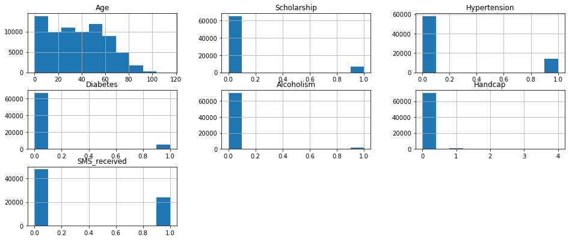

```python
# Use this, and more code cells, to explore your data. Don't forget to add
#   Markdown cells to document your observations and findings.
df.hist(figsize = (16,6.5));
```

**●Majority of the patients did not suffer from chronic deseases or they handicapped.**

```python
#sharing the patience to two groups according to showing or not showing
show = df.No_show == 'No'
noshow = df.No_show == 'Yes'
df[show].count(), df[noshow].count()
```

```
(Gender           54153
 Age              54153
 Neighbourhood    54153
 Scholarship      54153
 Hypertension     54153
 Diabetes         54153
 Alcoholism       54153
 Handcap          54153
 SMS_received     54153
 No_show          54153
 dtype: int64,
 Gender           17663
 Age              17663
 Neighbourhood    17663
 Scholarship      17663
 Hypertension     17663
 Diabetes         17663
 Alcoholism       17663
 Handcap          17663
 SMS_received     17663
 No_show          17663
 dtype: int64)
```

```python
df.head()
```

|  | Gender | Age | Neighbourhood | Scholarship | Hypertension | Diabetes | Alcoholism | Handcap | SMS_received | No_show |
| --- | --- | --- | --- | --- | --- | --- | --- | --- | --- | --- |
| 0 | F | 62 | JARDIM DA PENHA | 0 | 1 | 0 | 0 | 0 | 0 | No |
| 1 | M | 56 | JARDIM DA PENHA | 0 | 0 | 0 | 0 | 0 | 0 | No |
| 2 | F | 62 | MATA DA PRAIA | 0 | 0 | 0 | 0 | 0 | 0 | No |
| 3 | F | 8 | PONTAL DE CAMBURI | 0 | 0 | 0 | 0 | 0 | 0 | No |
| 4 | F | 56 | JARDIM DA PENHA | 0 | 1 | 1 | 0 | 0 | 0 | No |

**Number of those who showed at the clinic are 54153 allot more than those who did not show.**

```python
df.info()
```

```
<class 'pandas.core.frame.DataFrame'>
Int64Index: 71816 entries, 0 to 110524
Data columns (total 10 columns):
 #   Column         Non-Null Count  Dtype
---  ------         --------------  -----
 0   Gender         71816 non-null  object
 1   Age            71816 non-null  int64
 2   Neighbourhood  71816 non-null  object
 3   Scholarship    71816 non-null  int64
 4   Hypertension   71816 non-null  int64
 5   Diabetes       71816 non-null  int64
 6   Alcoholism     71816 non-null  int64
 7   Handcap        71816 non-null  int64
 8   SMS_received   71816 non-null  int64
 9   No_show        71816 non-null  object
dtypes: int64(7), object(3)
memory usage: 6.0+ MB
```

```python
df[show].mean(), df[noshow].mean()
```

```
(Age             37.229166
 Scholarship      0.091334
 Hypertension     0.202944
 Diabetes         0.072868
 Alcoholism       0.023600
 Handcap          0.020904
 SMS_received     0.297232
 dtype: float64,
 Age             34.376267
 Scholarship      0.108419
 Hypertension     0.170922
 Diabetes         0.065108
 Alcoholism       0.029440
 Handcap          0.017777
 SMS_received     0.453094
 dtype: float64)
```

**Mean age for patients that showed is 37 and mean age for patient that did not showed is 34.**

**Investigation of the influencing factors on the attendance rate**

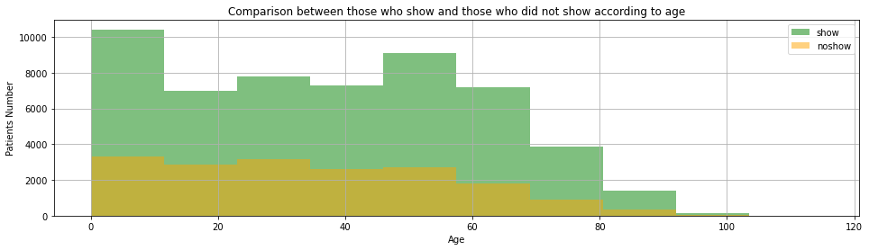

```python
#does age affect attendance
def attendance(df,col_name, attended, absent):#setting

    plt.figure(figsize = [16,4])
    df[col_name][show].hist(alpha=.5, bins=10, color = 'green', label = 'show')
    df[col_name][noshow].hist(alpha=.5, bins=10, color = 'orange', label = 'noshow')
    plt.legend()
    plt.title('Comparison between those who show and those who did not show according to age')
    plt.xlabel('Age')
    plt.ylabel('Patients Number');
attendance(df,'Age',show,noshow)
```

**Patients in age group 0-10 showed more than other age group then 45-55, the least who showed are from 60 and above.**

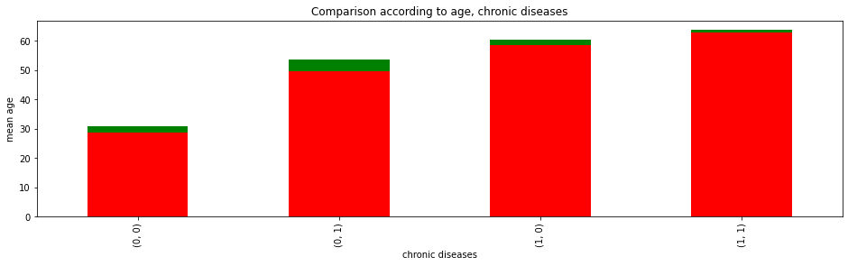

```python
#does age and cronic diseases affect attendance
plt.figure(figsize = (16,4))#setting the figure size
df[show].groupby(['Hypertension', 'Diabetes']).mean()['Age'].plot(kind = 'bar', color = 'green', label = 'show')
df[noshow].groupby(['Hypertension', 'Diabetes']).mean()['Age'].plot(kind = 'bar', color = 'red', label = 'noshow')
plt.title('Comparison according to age, chronic diseases')
plt.xlabel('chronic diseases')
plt.ylabel('mean age');
```

```python
df[show].groupby(['Hypertension', 'Diabetes']).mean()['Age'],df[noshow].groupby(['Hypertension', 'Diabetes']).mean()['Age']
```

```
(Hypertension  Diabetes
 0             0           30.713360
               1           53.701370
 1             0           60.270517
               1           63.764303
 Name: Age, dtype: float64,
 Hypertension  Diabetes
 0             0           28.768691
               1           49.481172
 1             0           58.650380
               1           62.913282
 Name: Age, dtype: float64)
```

**Does gender affect attendance**

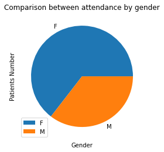

```python
#what is the percentage of sex attendance
def attendance(df,col_name, attended, absent):

    plt.figure(figsize = [16,4])
    df[col_name][show].value_counts(normalize=True).plot(kind = 'pie', label = 'show')
    plt.legend()
    plt.title('Comparison between attendance by gender')
    plt.xlabel('Gender')
    plt.ylabel('Patients Number');
attendance(df,'Gender',show,noshow)
```

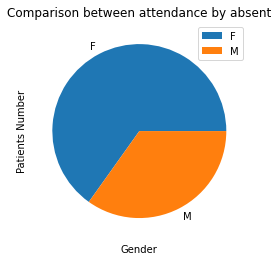

```python
#what is the percentage of sex absent
def attendance(df,col_name, attended, absent):

    plt.figure(figsize = [16,4])
    df[col_name][noshow].value_counts(normalize=True).plot(kind = 'pie', label = 'show')
    plt.legend()
    plt.title('Comparison between attendance by absent')
    plt.xlabel('Gender')
    plt.ylabel('Patients Number');
attendance(df,'Gender',show,noshow)
```

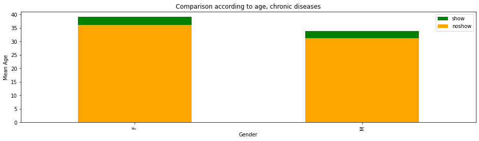

```python
#does age and cronic gender affect attendance together (checking by mean age)
plt.figure(figsize = (16,4))
df[show].groupby('Gender').Age.mean().plot(kind = 'bar', color = 'green', label = 'show')
df[noshow].groupby('Gender').Age.mean().plot(kind = 'bar', color = 'orange', label = 'noshow')
plt.legend()
plt.title('Comparison according to age, chronic diseases')
plt.xlabel('Gender')
plt.ylabel('Mean Age');
```

```python
print(df[show].groupby('Gender').Age.mean(),df[noshow].groupby('Gender').Age.mean(),
df[show].groupby('Gender').Age.median(),df[noshow].groupby('Gender').Age.median())
```

```
Gender
F    39.130292
M    33.766269
Name: Age, dtype: float64 Gender
F    36.06501
M    31.22040
Name: Age, dtype: float64 Gender
F    39.0
M    32.0
Name: Age, dtype: float64 Gender
F    34.0
M    29.0
Name: Age, dtype: float64
```

**There is no corelation between the gender and age affecting the show rate**

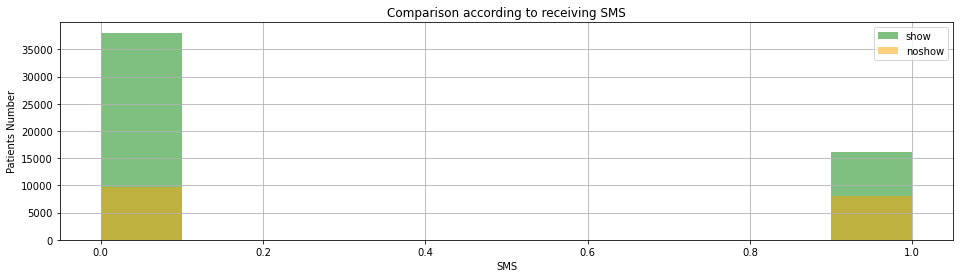

```python
#does receiving SMS affect attendance
def attendance(df,col_name, attended, absent):

    plt.figure(figsize = [16,4])
    df[col_name][show].hist(alpha=.5, bins=10, color = 'green', label = 'show')
    df[col_name][noshow].hist(alpha=.5, bins=10, color = 'orange', label = 'noshow')
    plt.legend()
    plt.title('Comparison according to receiving SMS')
    plt.xlabel('SMS')
    plt.ylabel('Patients Number');
attendance(df,'SMS_received',show,noshow)
```

**Number od patients that showed without receiving an SMS is more than those who received an SMS**

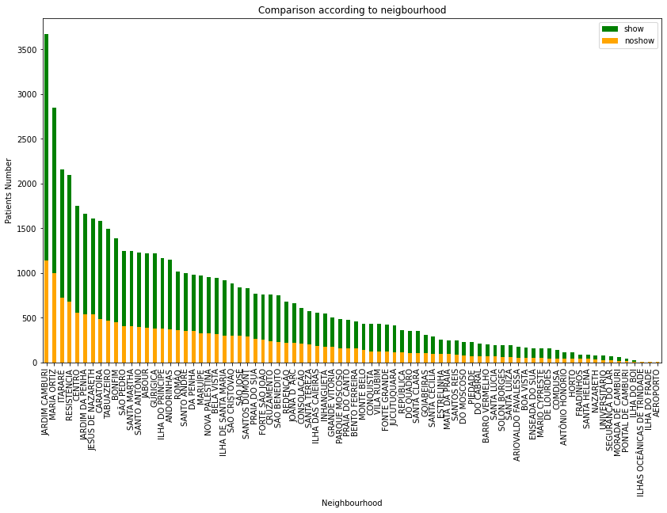

```python
#does neigbourhood affect attendance
plt.figure(figsize = (14,8))
df.Neighbourhood[show].value_counts().plot(kind = 'bar', color = 'green', label = 'show')
df.Neighbourhood[noshow].value_counts().plot(kind = 'bar', color = 'orange', label = 'noshow')
plt.legend()
plt.title('Comparison according to neigbourhood')
plt.xlabel('Neighbourhood')
plt.ylabel('Patients Number');
```

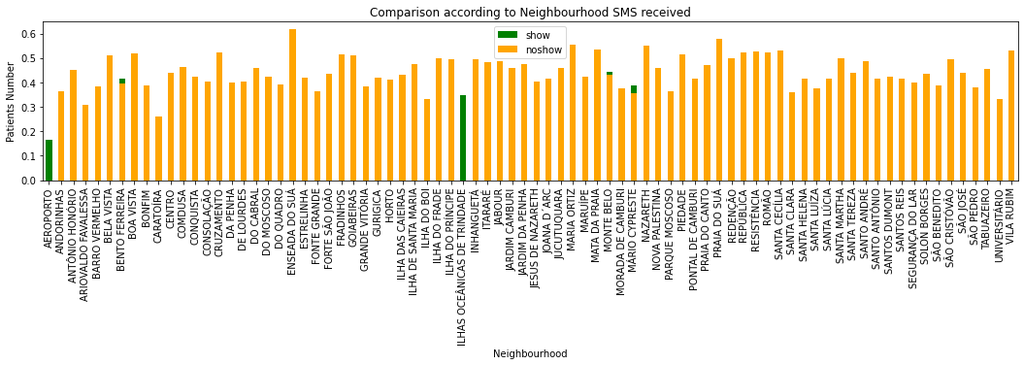

```python
plt.figure(figsize = (18,3))
df[show].groupby('Neighbourhood').SMS_received.mean().plot(kind = 'bar', color = 'green', label = 'show')
df[noshow].groupby('Neighbourhood').SMS_received.mean().plot(kind = 'bar', color = 'orange', label = 'noshow')
plt.legend()
plt.title('Comparison according to Neighbourhood SMS received')
plt.xlabel('Neighbourhood')
plt.ylabel('Patients Number');
```

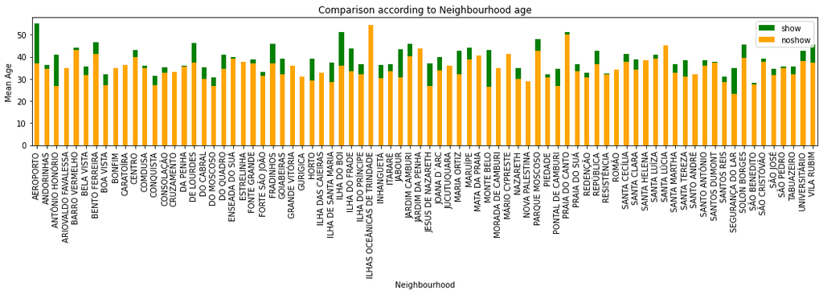

```python
plt.figure(figsize = (18,3))
df[show].groupby('Neighbourhood').Age.mean().plot(kind = 'bar', color = 'green', label = 'show')
df[noshow].groupby('Neighbourhood').Age.mean().plot(kind = 'bar', color = 'orange', label = 'noshow')
plt.legend()
plt.title('Comparison according to Neighbourhood age')
plt.xlabel('Neighbourhood')
plt.ylabel('Mean Age');
```

**Patients attendance from specific neigbourhood according to age differs**

## Conclusions

Number of patients showing up from specific neigbourhood was affected by age and receiving SMS.

Age has a clear influence on showing rate as patients in age group 0-10 showed more than other age group then 45-55, the least who showed are from 60 and above.

Number of showing patience without SMS is a lot more than showing with SMS.

**Limitations**

No clear connection between showing, gender, chronic diseases and enrollment in the Welfare program

```python
from subprocess import call
call(['python', '-m', 'nbconvert', 'Investigate_a_Dataset.ipynb'])
```

```
4294967295
```